# Angewandte Statistik Bachelor of Science

Workshop 2: Verteilungen von Wahrscheinlichkeiten

# Beurteilung von Verteilungen: Ordne zu.

**Aufgabe**

Im Datensatz ExampleDistributions.csv gibt es die Variablen `Data1`, `Data2` und `Data3`. Sie weisen Verteilungen auf, die sich bezüglich Symmetrie und Schiefe unterscheiden. Folgend die ersten 5 Zeilen aus dem Datensatz.

| Data1 | Data2 | Data3 |
| --- | --- | --- |
| 0.4997338 | 0.3136112 | -0.7287942 |
| -0.4432356 | 1.5153379 | -1.2396346 |
| -0.6650565 | -0.4076533 | -0.9054984 |
| 1.3623441 | 0.0393696 | 0.5040650 |
| -0.6604165 | 1.2876223 | 0.5130014 |

Die folgende Abbildung zeigt Histogramme, Boxplots und QQ-Plot der Variablen im Datensatz in zufälliger Anordnung. Gruppiere jeweils Histogramm, Boxplot und QQ-Plot jeder Variablen.

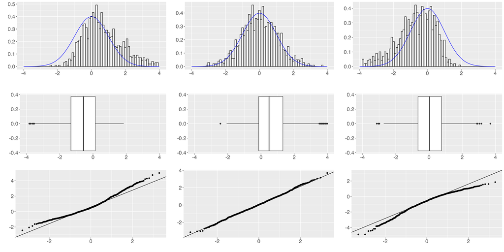

**Lösung**

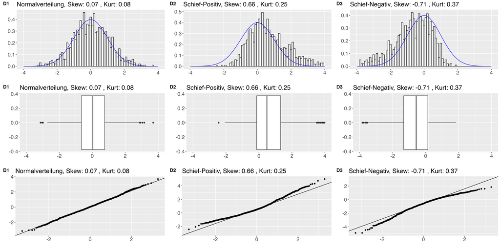

# Aufgabe 2

Flächen der Standard Normalverteilung

**Aufgabe**

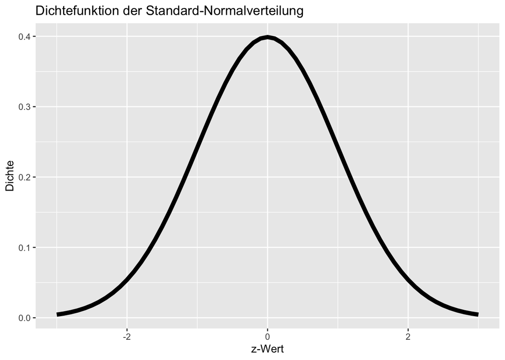

- Wie gross ist die gesamte Fläche unter der Standard-Normalverteilung?
- Wie gross ist die Fläche unter der Standard-Normalverteilung für $z \leq 0$?
- Wie gross ist die Fläche unter der Standard-Normalverteilung für $z \leq -1.96$?
- Wie gross ist die Fläche für $-1.96 \leq z \leq 1.96$?

**Lösung**

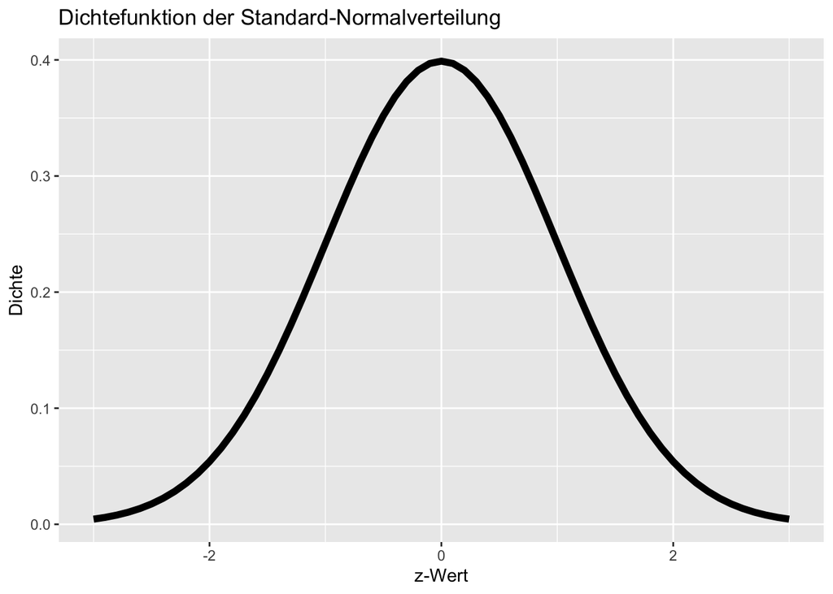

BSc_WS2_Verteilungen_Wahrschienlichkeit_Ex2_sol.omv

- Wie gross ist die gesamte Fläche unter der Standard-Normalverteilung?
  - Die gesamte Fläche ist 1 und entspricht der Wahrscheinlichkeit, dass ein Wert unter der Standard-Normalveteilung zwischen $\pm\infty$ liegt.
- Wie gross ist die Fläche unter der Standard-Normalverteilung für $z \leq 0$?
  - Da die Normalverteilung eine symmetrische Verteilung ist, beträgt die Fläche 0.5 und damit genau die Hälfte der Gesamtfläche.
- Wie gross ist die Fläche unter der Standard-Normalverteilung für $z \leq -1.96$?
  - Die Fläche beträgt 0.025.
- Wie gross ist die Fläche für $-1.96 \leq z \leq 1.96$?
  - Die Fläche beträgt 0.95.

# Aufgabe 3

Wahrscheinlichkeit der Normalverteilung.

**Aufgabe**

Für diese Aufgabe verwenden wir das Modul **distrAction** in jamovi.

Das Körpergewicht sei normalverteilt mit Mittelwert 65 kg und Standardabweichung 5 kg.

Frage: Wie gross ist die Wahrscheinlichkeit zwischen 55 kg und 75 kg zu wiegen?

**Lösung**

Das Körpergewicht sei normalverteilt mit Mittelwert 65 kg und Standardabweichung 5 kg.

Frage: Wie gross ist die Wahrscheinlichkeit zwischen 55 kg und 75 kg zu wiegen?

Die Wahrscheinlichkeit ist 95.5%. Sie entspricht dem 95.5% Bereich ist $\bar{x} \pm 2SD$

BSc_WS2_Verteilungen_Wahrschienlichkeit_Ex3_sol.omv

# Aufgabe 4

Wahrscheinlichkeit der Normalverteilung.

**Aufgabe**

Für diese Aufgabe verwenden wir das Modul **distrAction** in jamovi.

Das Körpergewicht sei normalverteilt mit Mittelwert 65 kg und Standardabweichung 5 kg.

Frage: Wie gross ist die Wahrscheinlichkeit zwischen 62.5 kg und 72.8 kg zu wiegen?

**Lösung**

Das Körpergewicht sei normalverteilt mit Mittelwert 65 kg und Standardabweichung 5 kg.

Frage: Wie gross ist die Wahrscheinlichkeit zwischen 62.5 kg und 72.8 kg zu wiegen?

Die Wahrscheinlichkeit beträgt 0.632.

BSc_WS2_Verteilungen_Wahrschienlichkeit_Ex4_sol.omv

# Aufgabe 5

Körpergewicht: Wahrscheinlichkeit und Quantile

**Aufgabe**

- Lade die Datei NHANES-BW-BH.csv
- Annahme: Normalverteilung mit Mittelwert und Standardabweichung des Körpergewichts in der vorliegenden Stichprobe.
- Wie schwer ist eine Person innerhalb des 95%-Normbereiches?
- Wie schwer muss eine Person mindestens sein, damit sie zu den 10% schwersten Personen gehört?
- Wie gross ist die Wahrscheinlichkeit, dass eine Person weniger oder 58 kg wiegt?
- Wie gross ist die Wahrscheinlichkeit, dass eine Person 58 kg oder mehr wiegt?

**Lösung**

BSc_WS2_Verteilung_Wahrscheinlichkeit_Ex5_sol.omv

- Annahme: Normalverteilung mit Mittelwert und Standardabweichung des Körpergewichts in der vorliegenden Stichprobe.
- Wie schwer ist eine Person innerhalb des 95%-Normbereiches?
  - Zwischen dem 0.025 und dem 0.975 Quantil der Normalverteilung mit Mittelwert 80.8 kg und Standardabweichung 20.9 kg: Zwischen 39.8 kg und 121.8 kg.
- Wie schwer muss eine Person mindestens sein, damit sie zu den 10% schwersten Personen gehört?
  - Dafür müssen wir das 0.9 Quantil (90. Perzentil) kennen: 107.6 kg.
- Wie gross ist die Wahrscheinlichkeit, dass eine Person weniger oder 58 kg wiegt?
  - Die Wahrscheinlichkeit ist 0.138.
- Wie gross ist die Wahrscheinlichkeit, dass eine Person 58 kg oder mehr wiegt?
  - Die Wahrscheinlichkeit ist 0.862.

**Codebook**

- `Koerpergroesse`: Körpergrösse in cm
- `Koerpergewicht`: Körpergewicht in kg
- `Geschlecht`: Geschlecht (1 = male, 2 = female)

# Aufgabe 6

Normalverteilung Geburtsgewicht.

**Aufgabe**

Das Geburtsgewicht von Neugeborenen nach unauffälliger Schwangerschaft sei mit Mittelwert 3500 Gramm und Standardabweichung 500 Gramm normalverteilt.

- Wie gross ist die Wahrscheinlichkeit, dass ein Neugeborenes aus dieser Grundgesamtheit mehr als 4700 Gramm wiegt?
- Finde eine Grenze für das Geburtsgewicht, die nur von 2.5% aller Neugeborenen übertroffen wird.

**Lösung**

BSc_WS2_Verteilungen_Wahrscheinlichkeit_Ex6_sol.omv

- Wie gross ist die Wahrscheinlichkeit, dass ein Neugeborenes aus dieser Grundgesamtheit mehr als 4700 Gramm wiegt?
  - Die Wahrscheinlichkeit beträgt 0.0082.
- Finde eine Grenze für das Geburtsgewicht, die nur von 2.5% aller Neugeborenen übertroffen wird.
  - Die Grenze beträgt 4480 Gramm.